# PSI-BLAST

## PSI-BLAST

```r
system2('psiblast', '-help', stdout = TRUE)
```

```
##   [1] "USAGE"
##   [2] "  psiblast [-h] [-help] [-import_search_strategy filename]"
##   [3] "    [-export_search_strategy filename] [-db database_name]"
##   [4] "    [-dbsize num_letters] [-gilist filename] [-seqidlist filename]"
##   [5] "    [-negative_gilist filename] [-negative_seqidlist filename]"
##   [6] "    [-taxids taxids] [-negative_taxids taxids] [-taxidlist filename]"
##   [7] "    [-negative_taxidlist filename] [-ipglist filename]"
##   [8] "    [-negative_ipglist filename] [-entrez_query entrez_query]"
##   [9] "    [-subject subject_input_file] [-subject_loc range] [-query input_file]"
##  [10] "    [-out output_file] [-evalue evalue] [-word_size int_value]"
##  [11] "    [-gapopen open_penalty] [-gapextend extend_penalty]"
##  [12] "    [-qcov_hsp_perc float_value] [-max_hsps int_value]"
##  [13] "    [-xdrop_ungap float_value] [-xdrop_gap float_value]"
##  [14] "    [-xdrop_gap_final float_value] [-searchsp int_value]"
##  [15] "    [-sum_stats bool_value] [-seg SEG_options] [-soft_masking soft_masking]"
```

[output cut: 376 more lines]

### Ejercicio 1

Revisa la ayuda del `psiblast` y corrige los errores del bloque de código siguiente antes de ejecutarlo:

```r
system2('psiblast',
        args = c('-query', 'goodHits.fa',
                 '-db', 'swissprot',
                 '-out', 'psiblast.out',
                 '-matrix', 'BLOSUM62',
                 '-outfmt', '7',
                 '-evalue', '0.01',
                 '-inclusion_ethresh', '0.01',
                 '-num_iterations', '5',
                 '-comp_based_stats', '1'))
```

### Ejercicio 2

Asegúrate de poder contestar las preguntas siguientes: 1. ¿Para qué sirve el parámetro `-num_iterations`? 2. ¿Cuál de los dos umbrales debería ser mayor, `-evalue` o `-inclusion_ethresh`? 3. Revisa los resultados: ¿Puedes diferenciar los de cada una de las *queries*? ¿Cuántas tablas de resultados se producen por cada *query*? ¿Identificas los casos en los que se alcanza convergencia?

## *Queries* individuales

Un problema con los resultados anteriores es que el mismo archivo reúne los resultados de todas las queries, lo que dificulta importar los datos a R. Además, de cada *query* se producen más de una tabla: tantas como iteraciones. Nos puede interesar solamente la última tabla de cada query. Una opción es ejecutar `psiblast` individualmente para cada secuencia original, y guardar la PSSM de la última iteración. Entonces, realizar una última ronda, usando la PSSM como query. Vamos por pasos.

Primero, sacamos una única proteína de “badHits.fa” (por ejemplo, la GAKI01000772.1), y la guardamos en el archivo “GAKI01000772.fa”, usando las funciones del paquete “Biostrings”.

```r
suppressMessages(library('Biostrings'))
badHits <- readAAStringSet('badHits.fa')
writeXStringSet(badHits['GAKI01000772.1'], 'GAKI01000772.fa')
```

A continuación, ejecutamos cuatro rondas de PSI-BLAST, usando `GAKI01000772.fa` como *query* y pidiendo que se guarde la PSSM de la última ronda:

```r
system2('psiblast',
        args = c('-query', 'GAKI01000772.fa',
                 '-db', 'swissprot',
                 '-out', 'prot1.out',
                 '-outfmt', '7',
                 '-evalue', '1',
                 '-inclusion_ethresh', '0.7',
                 '-num_iterations', '4',
                 '-save_pssm_after_last_round',
                 '-out_pssm', 'GAKI01000772.pssm',
                 '-comp_based_stats', '0'))
```

Y por último, usamos la PSSM guardada en `GAKI01000772.pssm` como *query* en una última ronda de PSI-BLAST:

```r
system2('psiblast',
        args = c('-in_pssm', 'GAKI01000772.pssm',
                 '-db', 'swissprot',
                 '-out', 'GAKI01000772_final.out',
                 '-outfmt', '7',
                 '-evalue', '1.e-60',
                 '-comp_based_stats', '0'))
```

### Ejercicio 3

Revisa los resultados y nota que en cada ronda se añaden nuevas secuencias, mientras que las encontradas previamente aparecen con valores E cada vez menores.

### Ejercicio 4

Repite el proceso para la proteína GAKI01003315.1.

## Importar los resultados a R

Una vez tenemos una única tabla, es sencillo leerla en R:

```r
library(kableExtra)
GAKI01000772 <- read.table(
   'GAKI01000772_final.out',
   col.names = c('query', 'subject', 'identity', 'length', 'mismatches',
                 'gaps', 'qstart', 'qend', 'sstart', 'send', 'evalue', 'bitscore')
)
kable(GAKI01000772) %>% kable_styling()
```

| query | subject | identity | length | mismatches | gaps | qstart | qend | sstart | send | evalue | bitscore |
| --- | --- | --- | --- | --- | --- | --- | --- | --- | --- | --- | --- |
| GAKI01000772.1 | Q95JC9.2 | 8.000 | 200 | 176 | 3 | 3 | 194 | 476 | 675 | 0 | 283 |
| GAKI01000772.1 | Q95JC9.2 | 9.479 | 211 | 177 | 5 | 2 | 198 | 454 | 664 | 0 | 282 |
| GAKI01000772.1 | Q95JC9.2 | 9.268 | 205 | 177 | 4 | 3 | 198 | 437 | 641 | 0 | 277 |
| GAKI01000772.1 | Q95JC9.2 | 8.586 | 198 | 176 | 3 | 3 | 195 | 226 | 423 | 0 | 277 |
| GAKI01000772.1 | Q95JC9.2 | 8.173 | 208 | 179 | 4 | 3 | 198 | 91 | 298 | 0 | 276 |
| GAKI01000772.1 | Q95JC9.2 | 8.654 | 208 | 178 | 5 | 3 | 198 | 133 | 340 | 0 | 276 |
| GAKI01000772.1 | Q95JC9.2 | 8.920 | 213 | 177 | 5 | 3 | 198 | 165 | 377 | 0 | 276 |
| GAKI01000772.1 | Q95JC9.2 | 8.173 | 208 | 179 | 4 | 3 | 198 | 175 | 382 | 0 | 276 |
| GAKI01000772.1 | Q95JC9.2 | 9.406 | 202 | 173 | 4 | 5 | 196 | 72 | 273 | 0 | 275 |
| GAKI01000772.1 | Q95JC9.2 | 10.345 | 203 | 175 | 4 | 3 | 198 | 112 | 314 | 0 | 275 |
| GAKI01000772.1 | Q95JC9.2 | 9.217 | 217 | 175 | 5 | 4 | 198 | 182 | 398 | 0 | 275 |
| GAKI01000772.1 | Q95JC9.2 | 8.756 | 217 | 176 | 5 | 4 | 198 | 77 | 293 | 0 | 275 |
| GAKI01000772.1 | Q95JC9.2 | 10.837 | 203 | 174 | 4 | 3 | 198 | 154 | 356 | 0 | 275 |
| GAKI01000772.1 | Q95JC9.2 | 9.901 | 202 | 176 | 3 | 3 | 198 | 207 | 408 | 0 | 275 |
| GAKI01000772.1 | Q95JC9.2 | 8.738 | 206 | 177 | 3 | 4 | 198 | 119 | 324 | 0 | 274 |
| GAKI01000772.1 | Q95JC9.2 | 9.045 | 199 | 176 | 3 | 3 | 196 | 79 | 277 | 0 | 273 |
| GAKI01000772.1 | Q95JC9.2 | 7.692 | 208 | 180 | 4 | 3 | 198 | 196 | 403 | 0 | 273 |
| GAKI01000772.1 | Q95JC9.2 | 7.658 | 222 | 179 | 4 | 3 | 198 | 289 | 510 | 0 | 273 |
| GAKI01000772.1 | Q95JC9.2 | 9.390 | 213 | 176 | 6 | 3 | 198 | 123 | 335 | 0 | 273 |
| GAKI01000772.1 | Q95JC9.2 | 9.375 | 224 | 174 | 4 | 4 | 198 | 371 | 594 | 0 | 273 |
| GAKI01000772.1 | Q95JC9.2 | 7.207 | 222 | 180 | 4 | 3 | 198 | 238 | 459 | 0 | 272 |
| GAKI01000772.1 | Q95JC9.2 | 7.658 | 222 | 179 | 4 | 3 | 198 | 259 | 480 | 0 | 271 |
| GAKI01000772.1 | Q95JC9.2 | 8.444 | 225 | 177 | 3 | 3 | 198 | 354 | 578 | 0 | 271 |
| GAKI01000772.1 | Q95JC9.2 | 8.658 | 231 | 176 | 5 | 3 | 198 | 301 | 531 | 0 | 271 |
| GAKI01000772.1 | Q95JC9.2 | 9.091 | 231 | 175 | 5 | 3 | 198 | 322 | 552 | 0 | 270 |
| GAKI01000772.1 | Q95JC9.2 | 9.091 | 231 | 175 | 7 | 3 | 198 | 343 | 573 | 0 | 270 |
| GAKI01000772.1 | Q95JC9.2 | 6.897 | 232 | 180 | 5 | 3 | 198 | 394 | 625 | 0 | 270 |
| GAKI01000772.1 | Q95JC9.2 | 8.955 | 201 | 171 | 3 | 10 | 198 | 72 | 272 | 0 | 266 |
| GAKI01000772.1 | Q95JC9.2 | 8.947 | 190 | 167 | 3 | 3 | 186 | 487 | 676 | 0 | 266 |
| GAKI01000772.1 | Q95JC9.2 | 8.879 | 214 | 177 | 3 | 3 | 198 | 43 | 256 | 0 | 264 |

[output cut: 76 more lines]

Y ahora podemos operar con los datos. Por ejemplo, para visualizar la distribución de alineamientos (o *hits*) a lo largo de la secuencia de la *query* y su valor E:

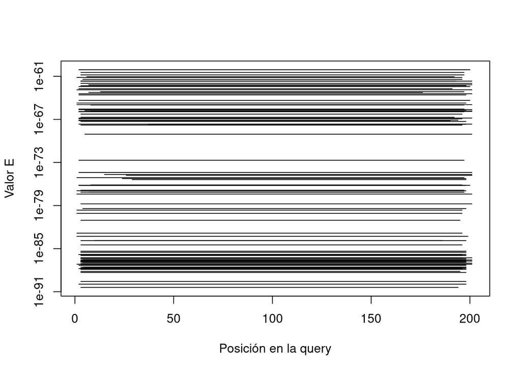

```r
# Primero creamos un gráfico vacío, con los límites adecuados y con
# una escala logarítmica en el eje vertical.
plot(x = c(1, width(badHits['GAKI01000772.1'])),
     y = c(min(GAKI01000772$evalue), max(GAKI01000772$evalue)),
     type = 'n',
     xlab = 'Posición en la query',
     ylab = 'Valor E',
     log = 'y')
# La función segments() añade segmentos a un gráfico preexistente.
segments(x0 = GAKI01000772$qstart,
         y0 = GAKI01000772$evalue,
         x1 = GAKI01000772$qend,
         y1 = GAKI01000772$evalue)
```

### Ejercicio 5

¿Sabrías obtener un gráfico que nos muestre la relación entre el valor E y el *bitscore*?

### Ejercicio 6

Interpreta el bloque siguiente y piensa para qué podría servir.

```r
library('rjson')
API <- 'https://www.ebi.ac.uk/interpro/api/'
subject <- unlist(strsplit(GAKI01000772$subject[1], '.', fixed = TRUE))[1]
informacion <- fromJSON(
   file = paste0(API, 'protein/reviewed/', subject)
)
```